# Module 1: Programming Fundamentals

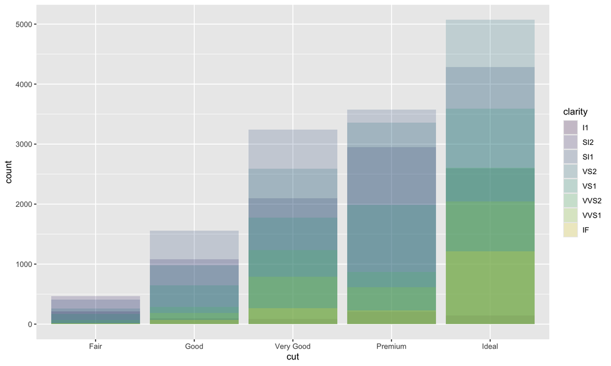

```r
# alter transparency
ggplot(diamonds, aes(x = cut, fill = clarity)) +
    geom_bar(alpha = 1/5, position = "identity")
```

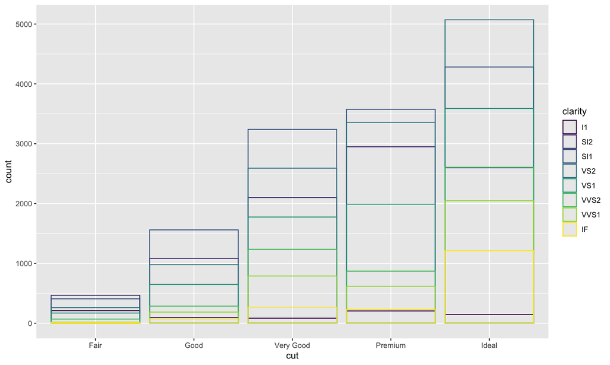

```r
# colour bar outlines with no fill colour
ggplot(diamonds, aes(x = cut, colour = clarity)) +
    geom_bar(fill = NA, position = "identity")
```

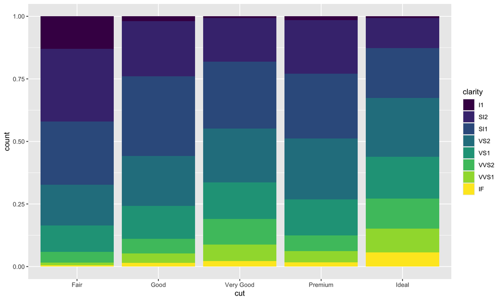

```r
# position = "fill" makes each set of stacked bars the same height
ggplot(diamonds) +
    geom_bar(aes(x = cut, fill = clarity), position = "fill")
```

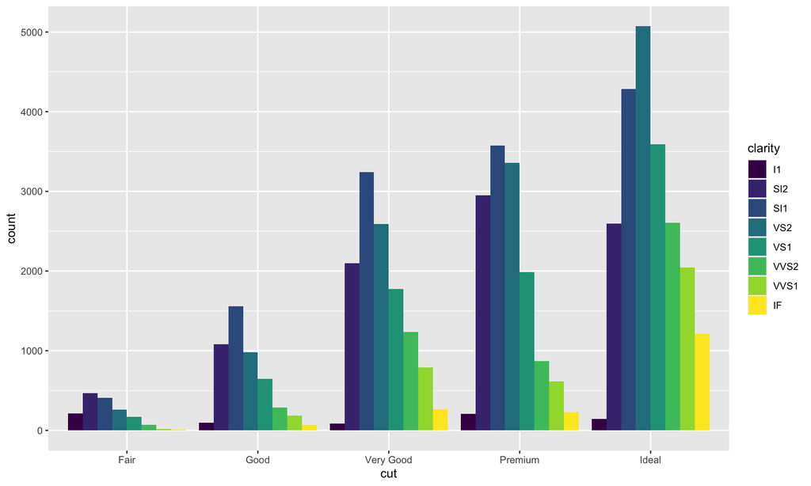

```r
ggplot(diamonds) +
    geom_bar(aes(x = cut, fill = clarity), position = "dodge")
```

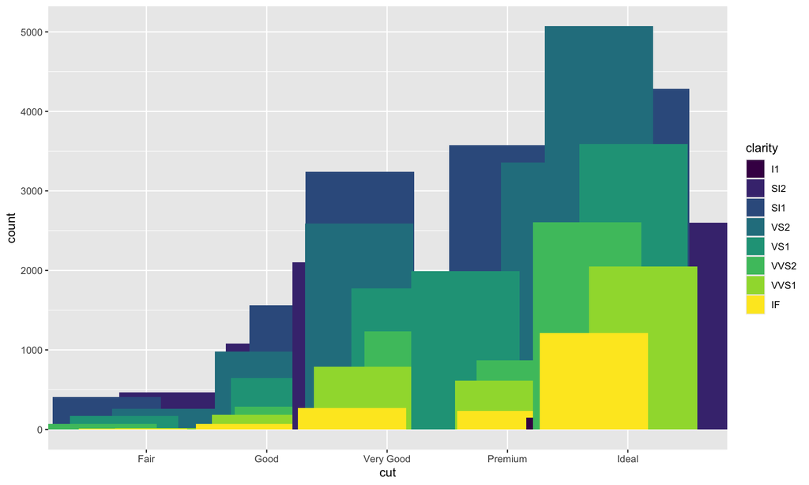

```r
# position = "jitter" adds small amount of random noise to each point to avoid overplotting when points overlap...good for scatterplots, not barplots
ggplot(diamonds) +
    geom_bar(aes(x = cut, fill = clarity), position = "jitter")
```

# 6 **Workshop 3: Reproducible Research in Marine Science**

**Note**

The R package library `usethis` **must** be installed and loaded in order to link your GitHub account to RStudio.

```r
# in the console:
  # credentials::git_credential_ask()
  # usethis::git_sitrep()

# in the console:
  # usethis::use_git()

# after staging and committing files from the Git pane, in the console:
  # usethis::use_github()

# in RStudio terminal:
  # git remote add origin https://github.com/katiedyck/MB5370_Module01.git
  # git push -u origin master
# this created a master branch in the repository in GitHub, and the files `.gitignore` and `MB5370_Module01.git` are now visible

# in RStudio terminal:
  # git push
```

# 7 **Workshop 4: Developers Toolbox & AI**

## 7.1 GitHub Copilot

All 3 of the graphs below were created using Copilot, an AI coding assistant that can generate code based on natural language prompts. Comments in the code chunks indicate the prompts used to generate the code for each graph.

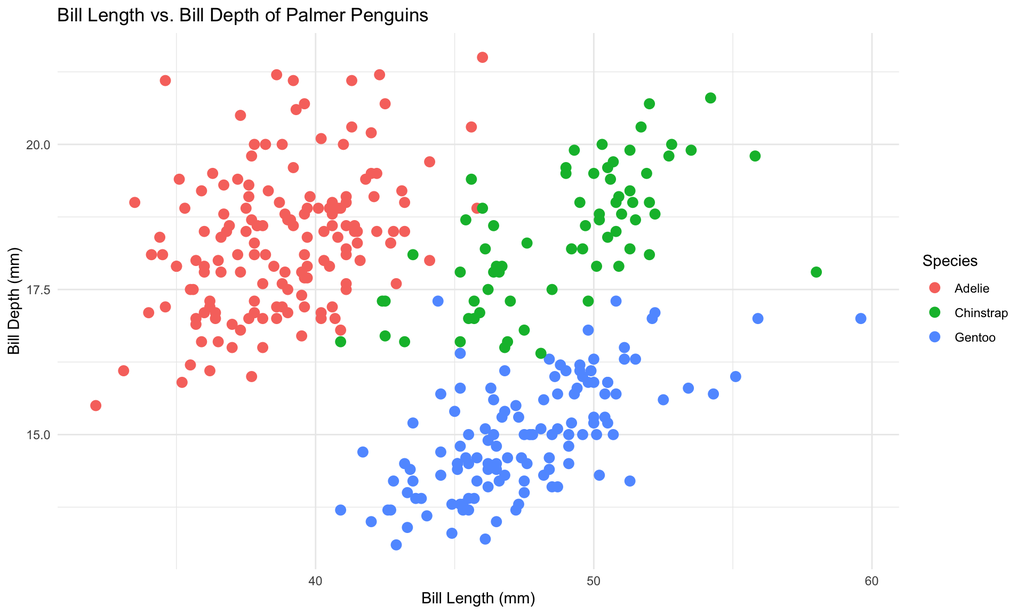

```r
# Load tidyverse and palmerpenguins libraries
library(tidyverse)
library(palmerpenguins)

# Create a ggplot scatter plot using the penguins dataset.
# Plot bill_length_mm on the x-axis and bill_depth_mm on the y-axis.
# Color points by species and use geom_point with size 3.
# Add a minimal theme and clean labels.
ggplot(penguins, aes(x = bill_length_mm, y = bill_depth_mm, color = species)) +
  geom_point(size = 3) +
  theme_minimal() +
  labs(
    title = "Bill Length vs. Bill Depth of Palmer Penguins",
    x = "Bill Length (mm)",
    y = "Bill Depth (mm)",
    color = "Species"
  )
```

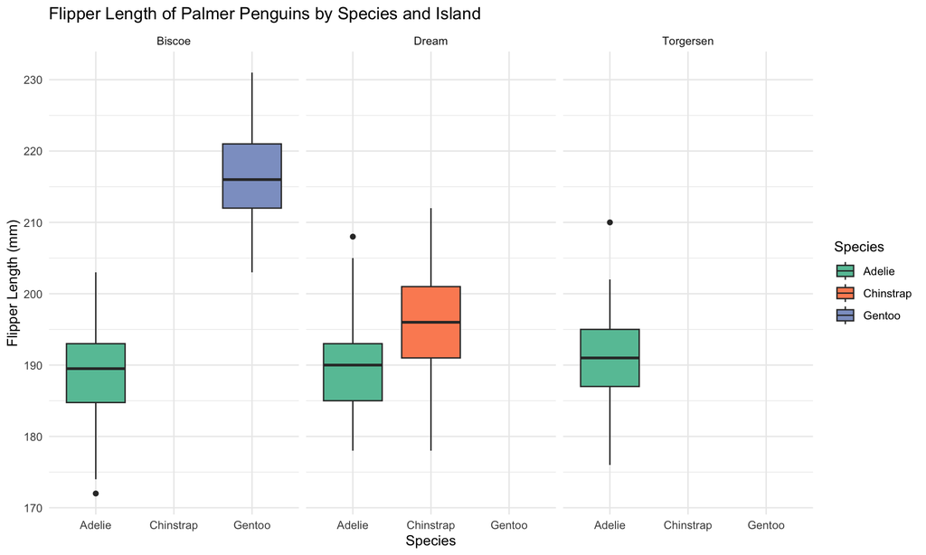

```r
# Create a ggplot boxplot using the penguins dataset.
# Compare flipper_length_mm across different species.
# Facet by island.
# Use custom color palettes.
ggplot(penguins, aes(x = species, y = flipper_length_mm, fill = species)) +
  geom_boxplot() +
  facet_wrap(~ island) +
  scale_fill_brewer(palette = "Set2") +
  theme_minimal() +
  labs(
    title = "Flipper Length of Palmer Penguins by Species and Island",
    x = "Species",
    y = "Flipper Length (mm)",
    fill = "Species"
  )
```

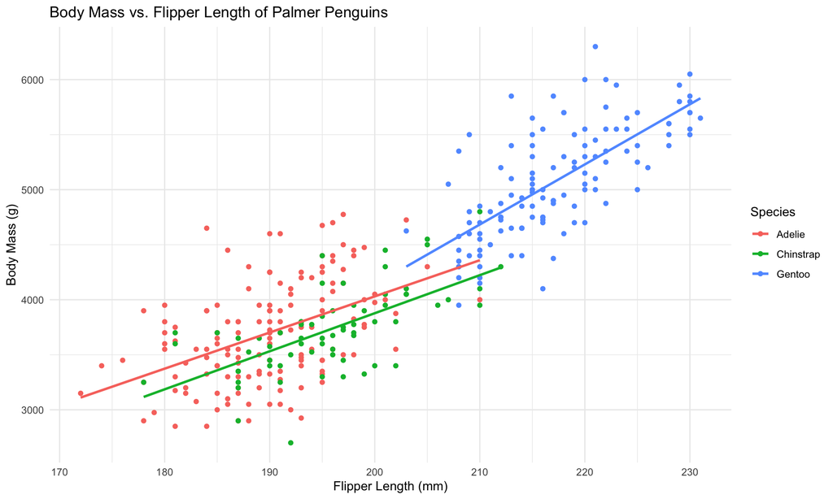

```r
# Create a ggplot scatterplot using the penguins dataset.
# Compare body_mass_g against flipper_length_mm.
# Add a linear regression trend line with geom_smooth(method = "lm") for each species.
ggplot(penguins, aes(x = flipper_length_mm, y = body_mass_g, color = species)) +
  geom_point() +
  geom_smooth(method = "lm", se = FALSE) +
  theme_minimal() +
  labs(
    title = "Body Mass vs. Flipper Length of Palmer Penguins",
    x = "Flipper Length (mm)",
    y = "Body Mass (g)",
    color = "Species"
  )
```

## 7.2 Google Gemini & `chattr`

The code below was run in the R Console to install Google Gemini and the `chattr` library before connecting them to RStudio.

```r
# in the console --> usethis::edit_r_environ()
  # in the console --> GEMINI_API_KEY="<my_custom_code>"
  # save the .Renviron file
# restart R (Command+Shift+0)


# Connecting `chattr` pkg to my model:
  # usethis::edit_r_profile()
    # options(.chattr_chat = ellmer::chat_google_gemini()) --> save the .Rprofile file
# restart R (Command+Shift+0)

# To interact with `chattr`, type into the console:
  # chattr::chattr_app()
# or use my keyboard shortcut (Ctrl + Command + C)
```

## 7.3 `if()` / `else()`

```r
# Simple Example: Checking Sea Surface Temperature (SST)
sst <- 30.2

if (sst > 29.5) {
  print("Warning: Marine heatwave threshold exceeded!")
} else {
  print("SST remains within baseline parameters.")
}
```

```
[1] "Warning: Marine heatwave threshold exceeded!"
```

## 7.4 `if_else()` / `case_when()`

```r
# Sample coral data
coral_monitoring <- tibble(
  site = c("Site_A", "Site_B", "Site_C"),
  depth_m = c(12, 35, 8)
)

# Classify depth using if_else
coral_monitoring <- coral_monitoring %>%
  mutate(zone = if_else(depth_m > 30, "Deep Reef", "Shallow Reef"))
coral_monitoring
```

```
# A tibble: 3 × 3
  site   depth_m zone
  <chr>    <dbl> <chr>
1 Site_A      12 Shallow Reef
2 Site_B      35 Deep Reef
3 Site_C       8 Shallow Reef
```

- `mutate()` creates a new column in the tibble based on the if_else condition - if the reef is deeper than 30 meters it is classified as a Deep Reef, otherwise it is classified as a Shallow Reef.
- `%>%` is the **pipe operator**. It allows you to pass a series of expressions; it passes the result of the expression that’s on the left of the pipe as the first argument for the right-hand side function.

```r
coral_monitoring <- coral_monitoring %>%
  mutate(reef_category = case_when(
    depth_m < 10  ~ "Lagoon / Flats",
    depth_m <= 30 ~ "Crest / Slope",
    depth_m > 30  ~ "Mesophotic / Deep",
    TRUE          ~ "Unclassified" # Catch-all remainder
  ))
coral_monitoring
```

```
# A tibble: 3 × 4
  site   depth_m zone         reef_category
  <chr>    <dbl> <chr>        <chr>
1 Site_A      12 Shallow Reef Crest / Slope
2 Site_B      35 Deep Reef    Mesophotic / Deep
3 Site_C       8 Shallow Reef Lagoon / Flats
```

When you have more than two possibilities, stacking multiple if-else blocks becomes unreadable. case_when() provides a clean, sequential evaluation layout using formula tildes (`~`).

## 7.5 Create a tibble with `chattr`

The code below was creating by entering the comment into `chattr`.

```r
# Write a script that creates a tibble named marine_stations that contains a column called salinity with values 35, 28, 32, and 12. Use the pipe operator (%>%) and mutate() combined with case_when() to create a new column called environment_type. Classify values below 15 as "Estuarine", values between 15 and 30 as "Brackish", and values above 30 as "Marine".

marine_stations <- tibble(salinity = c(35, 28, 32, 12)) %>%
  mutate(
    environment_type = case_when(
      salinity < 15 ~ "Estuarine",
      salinity >= 15 & salinity <= 30 ~ "Brackish",
      salinity > 30 ~ "Marine",
      TRUE ~ NA_character_ # Catch-all for any other cases, though not strictly needed here
    )
  )

marine_stations
```

```
# A tibble: 4 × 2
  salinity environment_type
     <dbl> <chr>
1       35 Marine
2       28 Brackish
3       32 Marine
4       12 Estuarine
```

## 7.6 for loops

```r
# Classic loop anatomy
for (year in 2020:2024) {
  print(paste("Processing climate data for year:", year))
}
```

```
[1] "Processing climate data for year: 2020"
[1] "Processing climate data for year: 2021"
[1] "Processing climate data for year: 2022"
[1] "Processing climate data for year: 2023"
[1] "Processing climate data for year: 2024"
```

```r
# Loop across index sequences
transect_lengths <- c(50, 100, 25, 75)

for (i in seq_along(transect_lengths)) {
  print(paste("Transect number", i, "measures", transect_lengths[i], "metres."))
}
```

```
[1] "Transect number 1 measures 50 metres."
[1] "Transect number 2 measures 100 metres."
[1] "Transect number 3 measures 25 metres."
[1] "Transect number 4 measures 75 metres."
```

```r
number_turtles <- c(17, 39, 56, 44)
for (i in number_turtles) {
  print(paste("There were", i, "turtles on the beach last night."))
}
```

```
[1] "There were 17 turtles on the beach last night."
[1] "There were 39 turtles on the beach last night."
[1] "There were 56 turtles on the beach last night."
[1] "There were 44 turtles on the beach last night."
```

## 7.7 Programming with the `purrr` package

Different map functions in the `purrr` package map a specific operation onto every item in a list or vector, automatically ensuring that your output matches the precise data structure you expect.

```r
# Using a standard for-loop:
site_areas <- c(144, 400, 625)
results <- numeric(length(site_areas))  # Must build an empty container first

for(i in seq_along(site_areas)) {
  results[i] <- sqrt(site_areas[i])
}
results
```

```
[1] 12 20 25
```

```r
# Using the purrr equivalent:
# Map directly and define your expected output type explicitly
mapped_results <- map_dbl(site_areas, sqrt)
mapped_results
```

```
[1] 12 20 25
```

```r
# purrr pipelines can be combined inside data frames to split analyses across separate groups:
iris %>%
  split(.$Species) %>%
  map(~summary(.x))     # iterate a summary function over split lists of data
```

```
$setosa
  Sepal.Length    Sepal.Width     Petal.Length    Petal.Width
 Min.   :4.300   Min.   :2.300   Min.   :1.000   Min.   :0.100
 1st Qu.:4.800   1st Qu.:3.200   1st Qu.:1.400   1st Qu.:0.200
 Median :5.000   Median :3.400   Median :1.500   Median :0.200
 Mean   :5.006   Mean   :3.428   Mean   :1.462   Mean   :0.246
 3rd Qu.:5.200   3rd Qu.:3.675   3rd Qu.:1.575   3rd Qu.:0.300
 Max.   :5.800   Max.   :4.400   Max.   :1.900   Max.   :0.600
       Species
 setosa    :50
 versicolor: 0
 virginica : 0




$versicolor
  Sepal.Length    Sepal.Width     Petal.Length   Petal.Width          Species
 Min.   :4.900   Min.   :2.000   Min.   :3.00   Min.   :1.000   setosa    : 0
 1st Qu.:5.600   1st Qu.:2.525   1st Qu.:4.00   1st Qu.:1.200   versicolor:50
 Median :5.900   Median :2.800   Median :4.35   Median :1.300   virginica : 0
 Mean   :5.936   Mean   :2.770   Mean   :4.26   Mean   :1.326
 3rd Qu.:6.300   3rd Qu.:3.000   3rd Qu.:4.60   3rd Qu.:1.500
 Max.   :7.000   Max.   :3.400   Max.   :5.10   Max.   :1.800

$virginica
  Sepal.Length    Sepal.Width     Petal.Length    Petal.Width
 Min.   :4.900   Min.   :2.200   Min.   :4.500   Min.   :1.400
 1st Qu.:6.225   1st Qu.:2.800   1st Qu.:5.100   1st Qu.:1.800
 Median :6.500   Median :3.000   Median :5.550   Median :2.000
 Mean   :6.588   Mean   :2.974   Mean   :5.552   Mean   :2.026
 3rd Qu.:6.900   3rd Qu.:3.175   3rd Qu.:5.875   3rd Qu.:2.300
 Max.   :7.900   Max.   :3.800   Max.   :6.900   Max.   :2.500
       Species
 setosa    : 0
 versicolor: 0
 virginica :50
```

```r
# From chattr prompt: "I have a list of three vectors containing fish count data. Write a for-loop to calculate the mean of each, and then show me the exact parallel way to do it using purrr's map_dbl function."

# Sample data
fish_counts_list <- list(
  river_a = c(10, 12, 8, 15, 11),
  lake_b = c(25, 22, 28, 20, 26, 24),
  stream_c = c(5, 7, 6, 9)
)

# Using a for-loop
mean_counts_for <- vector("numeric", length(fish_counts_list))
names(mean_counts_for) <- names(fish_counts_list)

for (i in seq_along(fish_counts_list)) {
  mean_counts_for[i] <- mean(fish_counts_list[[i]])
}

mean_counts_for
```

```
 river_a   lake_b stream_c
11.20000 24.16667  6.75000
```

```r
# Using purrr map function:
mean_counts_map <- map_dbl(fish_counts_list, mean)
mean_counts_map
```

```
 river_a   lake_b stream_c
11.20000 24.16667  6.75000
```

## 7.8 Writing custom functions

```r
# Function Definition
calculate_coral_mortality <- function(initial_count, surviving_count) {

  # Logic safety switch using our conditional tools!
  if (initial_count <= 0) {
    stop("Initial count must be greater than zero.")
  }

  mortality_rate <- (initial_count - surviving_count) / initial_count
  return(mortality_rate)

}

# Utilizing your custom function
calculate_coral_mortality(initial_count = 120, surviving_count = 84)
```

```
[1] 0.3
```

```r
# Custom function: convert temperature from degrees celcius to degrees fahrenheit
convert_temp_c_to_f <- function(C) {

  # conditional safety check
  if (C < -273.15) {
    stop("Cannot be below absolute zero!")
  }

  fahrenheit <- (C * 9/5) + 32
  #return(fahrenheit)
  print(paste(C, "\u00B0C =", round(fahrenheit, digits = 2), "\u00B0F."))
}

convert_temp_c_to_f(22)
```

```
[1] "22 °C = 71.6 °F."
```

```r
convert_temp_c_to_f(50)
```

```
[1] "50 °C = 122 °F."
```

```r
convert_temp_c_to_f(35)
```

```
[1] "35 °C = 95 °F."
```

```r
convert_temp_c_to_f(-16)
```

```
[1] "-16 °C = 3.2 °F."
```

## 7.9 Advanced Scripting Challenges

The paragraphs in the comments below were entered into `chattr` to generate my code.

### 7.9.1 Challenge 1: Nested Multi-Vector Iteration

```r
# Given a vector of raw survey counts, counts <- c(15, 24, 8, 42), and a vector of species-specific scaling factors, factors <- c(1.2, 0.8, 2.5, 1.1), write a mapping statement that iterates across both vectors simultaneously to return a single vector of scaled abundance values. Do not use a manual index loop.

counts <- c(15, 24, 8, 42)
factors <- c(1.2, 0.8, 2.5, 1.1)

map2_dbl(counts, factors, .f = `*`)
```

```
[1] 18.0 19.2 20.0 46.2
```

### 7.9.2 Challenge 2: The Robust Data Wrangling Pipeline Function

```r
# Create a custom function, "clean_and_classify_survey", that can handle complex data frame structures. The function must be able to: accept a data frame (df) and a column name threshold parameter as inputs; safely check if the specified column name exists within the passed data frame, if not it triggers a user-friendly error message using stop(); filter out rows containing missing values (NA) within the specific column; use the pipe operator and mutate() along with a vectorised conditional (if_else() or case_when()) to append a status string variable classification based on the threshold parameter; return the cleaned, altered data frame to the global environment. Test the custom pipeline using a mock tibble that contains at least one missing value to confirm the code handles anomalies without crashing.

clean_and_classify_survey <- function(df, column_name, threshold) {
  # Safely check if the specified column name exists
  if (!column_name %in% names(df)) {
    stop(paste0("Error: Column '", column_name, "' not found in the data frame."))
  }

  # Convert column_name to a symbol for tidy evaluation
  col_sym <- sym(column_name)

  df_cleaned <- df %>%
    # Filter out rows containing missing values (NA) within the specific column
    filter(!is.na(!!col_sym)) %>%
    # Append a status string variable classification based on the threshold
    mutate(status = if_else(!!col_sym >= threshold, "High Performer", "Low Performer"))

  return(df_cleaned)
}

# Create a mock tibble for testing
mock_survey_data <- tibble(
  respondent_id = 101:105,
  satisfaction_score = c(85, NA, 92, 78, 60),
  feedback_category = c("Positive", "Neutral", "Positive", "Negative", "Neutral"),
  completion_date = as.Date(c("2023-10-26", "2023-10-27", "2023-10-28", "2023-10-29", "2023-10-30"))
)
print(mock_survey_data)
```

```
# A tibble: 5 × 4
  respondent_id satisfaction_score feedback_category completion_date
          <int>              <dbl> <chr>             <date>
1           101                 85 Positive          2023-10-26
2           102                 NA Neutral           2023-10-27
3           103                 92 Positive          2023-10-28
4           104                 78 Negative          2023-10-29
5           105                 60 Neutral           2023-10-30
```

```r
# Test 1: Happy path with existing column and NAs
cleaned_data_1 <- clean_and_classify_survey(
  df = mock_survey_data,
  column_name = "satisfaction_score",
  threshold = 80
)
print(cleaned_data_1)
```

```
# A tibble: 4 × 5
  respondent_id satisfaction_score feedback_category completion_date status
          <int>              <dbl> <chr>             <date>          <chr>
1           101                 85 Positive          2023-10-26      High Perfo…
2           103                 92 Positive          2023-10-28      High Perfo…
3           104                 78 Negative          2023-10-29      Low Perfor…
4           105                 60 Neutral           2023-10-30      Low Perfor…
```

```r
# Test 2: Verify error handling for a non-existent column
# This will stop execution and print the custom error message
    # cleaned_data_2 <- clean_and_classify_survey(
    #   df = mock_survey_data,
    #   column_name = "non_existent_column",
    #   threshold = 80
    # )
```